# Enrichment Analysis of H3K27ac peaks (enhancer)

last changed: 2023-08-29

# Annotation of H3K27ac peaks to enhancers

## Load data

To annotate the peaks to the corresponding enhacner regions/genes the list with all peaks is required as well as a list containing all enhancer target genes and regions. The annotation list was then filtered for only high scoring targets.

```r
> peaks <- readRDS("./Data/peaks_H3K27ac.rds")
> head(peaks)
```

```
## $cluster_1
## GRanges object with 1414 ranges and 0 metadata columns:
##          seqnames              ranges strand
##             <Rle>           <IRanges>  <Rle>
##      [1]     chr1     1247714-1248873      *
##      [2]     chr1     6489342-6492512      *
##      [3]     chr1     7249625-7251186      *
##      [4]     chr1     7294178-7295015      *
##      [5]     chr1     7296028-7304174      *
##      ...      ...                 ...    ...
##   [1410]     chrX 134603458-134605888      *
##   [1411]     chrX 134688117-134689537      *
##   [1412]     chrX 134692193-134693109      *
##   [1413]     chrX 151917684-151919957      *
##   [1414]     chrX 154001746-154003034      *
##   -------
##   seqinfo: 27 sequences from an unspecified genome; no seqlengths
##
## $cluster_2
## GRanges object with 1485 ranges and 0 metadata columns:
##          seqnames              ranges strand
##             <Rle>           <IRanges>  <Rle>
##      [1]     chr1     1693797-1694533      *
##      [2]     chr1     3624157-3625723      *
##      [3]     chr1     3678537-3678916      *
##      [4]     chr1     7548713-7551013      *
##      [5]     chr1     8268601-8270043      *
##      ...      ...                 ...    ...
##   [1481]     chrX 106917534-106918580      *
##   [1482]     chrX 150199393-150203588      *
##   [1483]     chrX 153469582-153472697      *
##   [1484]     chrX 154726930-154728979      *
##   [1485]     chrX 154750424-154751470      *
##   -------
##   seqinfo: 27 sequences from an unspecified genome; no seqlengths
##
## $cluster_3
## GRanges object with 1885 ranges and 0 metadata columns:
##          seqnames              ranges strand
##             <Rle>           <IRanges>  <Rle>
```

[output cut: 16 more lines]

```
##          seqnames              ranges strand
##             <Rle>           <IRanges>  <Rle>
##      [1]     chr1     7311995-7314407      *
##      [2]     chr1     8941172-8943832      *
##      [3]     chr1   10414942-10416287      *
##      [4]     chr1   14475937-14478853      *
##      [5]     chr1   14484916-14488449      *
##      ...      ...                 ...    ...
##   [1383]     chrX   69191250-69194266      *
##   [1384]     chrX   74448496-74453288      *
##   [1385]     chrX   74457919-74459557      *
##   [1386]     chrX 134620893-134624502      *
##   [1387]     chrX 134674762-134677721      *
##   -------
##   seqinfo: 27 sequences from an unspecified genome; no seqlengths
```

```r
> GH.region <- import("./Data/GeneHancer_regions.bed")
> head(GH.region)
```

```
## GRanges object with 6 ranges and 1 metadata column:
##       seqnames              ranges strand |        name
##          <Rle>           <IRanges>  <Rle> | <character>
##   [1]     chr1 243718002-243720199      * | GH01J243718
##   [2]     chr1 243731337-243731779      * | GH01J243731
##   [3]     chr1 243732184-243733170      * | GH01J243732
##   [4]     chr1 243736402-243741399      * | GH01J243739
##   [5]     chr1 243742401-243743402      * | GH01J243742
##   [6]     chr1 243785601-243787800      * | GH01J243786
##   -------
##   seqinfo: 24 sequences from an unspecified genome; no seqlengths
```

```r
> GH.anno.txt <- read.table("./Data/GeneHancer_annotation.txt", header = T)
> head(GH.anno.txt)
```

```
##          GHid              symbol combined_score is_elite
## 1 GH11J010511 12SribosomalRNA-001       250.6657        1
## 2 GH11J010512 12SribosomalRNA-001       250.6657        1
## 3 GH11J010508 12SribosomalRNA-001       250.6657        1
## 4 GH11J010509 12SribosomalRNA-001       250.6657        1
## 5 GH11J010510 12SribosomalRNA-001       250.6657        1
## 6 GH15J072047          1A9N_Q-001       250.6657        1
```

```r
> # filter for high scores in alignment:
> GH.anno.elite <- GH.anno.txt[which(GH.anno.txt$is_elite == 1), ]
> paged_table(GH.anno.elite)
```

|  | GHid | symbol | combined_score | is_elite |
| --- | --- | --- | --- | --- |
| 1 | GH11J010511 | 12SribosomalRNA-001 | 250.665688 | 1 |
| 2 | GH11J010512 | 12SribosomalRNA-001 | 250.665688 | 1 |
| 3 | GH11J010508 | 12SribosomalRNA-001 | 250.665688 | 1 |
| 4 | GH11J010509 | 12SribosomalRNA-001 | 250.665688 | 1 |
| 5 | GH11J010510 | 12SribosomalRNA-001 | 250.665688 | 1 |
| 6 | GH15J072047 | 1A9N_Q-001 | 250.665688 | 1 |
| 7 | GH15J072044 | 1A9N_Q-001 | 250.665688 | 1 |
| 8 | GH03J128074 | 1A9N_Q-002 | 250.665688 | 1 |
| 9 | GH03J128073 | 1A9N_Q-002 | 250.665688 | 1 |
| 12 | GH06J089063 | 1A9N_Q-003 | 250.665688 | 1 |

[output cut: 9990 more lines]

## Find enhancer regions and annotate gene IDs

Next, these list were used to find the corresponding enhancers using the first list (`GH.region`) with the function `findOverlaps`. Then the target genes were annotated using the second list (`GH.anno.elite`).

```r
> enhcr.H3ac <- peaks
>
> for (x in 1:4) {
+   curr.peaks <- peaks[[x]]
+   hits <- findOverlaps(curr.peaks, subject = GH.region)
+   overlap.H3ac <- peaks[[x]][hits@from, ]
+   mcols(overlap.H3ac)$GHid <- mcols(GH.region[hits@to, "name"])
+   df.over <- as.data.frame(overlap.H3ac)
+   mcols(overlap.H3ac)$symbol <- NA
+   ind <- intersect(df.over$name, GH.anno.elite$GHid)
+   mcols(overlap.H3ac)[which(df.over$name %in% ind), "symbol"] <-
+     GH.anno.elite[which(GH.anno.elite$GHid %in% ind), "symbol"]
+   mcols(overlap.H3ac)[which(df.over$name %in% ind), "score"] <-
+     GH.anno.elite[which(GH.anno.elite$GHid %in% ind), "combined_score"]
+   enhcr.H3ac[[x]] <- overlap.H3ac
+ }
>
> saveRDS(enhcr.H3ac, "./Data/Enhancer2gene.rds")
>
> head(enhcr.H3ac)
```

```
## $cluster_1
## GRanges object with 1802 ranges and 3 metadata columns:
##          seqnames              ranges strand |        GHid        symbol
##             <Rle>           <IRanges>  <Rle> | <DataFrame>   <character>
##      [1]     chr1     1247714-1248873      * | GH01J001250    4L8R_A-001
##      [2]     chr1     6489342-6492512      * | GH01J006487    4L8R_A-004
##      [3]     chr1     7249625-7251186      * | GH01J007250          <NA>
##      [4]     chr1     7249625-7251186      * | GH01J007249          <NA>
##      [5]     chr1     7294178-7295015      * | GH01J007293          <NA>
##      ...      ...                 ...    ... .         ...           ...
##   [1798]     chrX 134603458-134605888      * | GH0XJ134604 piR-45458-001
##   [1799]     chrX 134688117-134689537      * | GH0XJ134688          <NA>
##   [1800]     chrX 134692193-134693109      * | GH0XJ134691          <NA>
##   [1801]     chrX 151917684-151919957      * | GH0XJ151918 piR-45862-011
##   [1802]     chrX 154001746-154003034      * | GH0XJ154001 piR-46002-325
##              score
##          <numeric>
##      [1]   250.666
##      [2]   250.666
##      [3]        NA
##      [4]        NA
##      [5]        NA
##      ...       ...
##   [1798]   250.666
##   [1799]        NA
##   [1800]        NA
##   [1801]   250.666
##   [1802]   250.666
##   -------
##   seqinfo: 27 sequences from an unspecified genome; no seqlengths
##
## $cluster_2
## GRanges object with 1788 ranges and 3 metadata columns:
##          seqnames              ranges strand |        GHid       symbol
##             <Rle>           <IRanges>  <Rle> | <DataFrame>  <character>
##      [1]     chr1     1693797-1694533      * | GH01J001691   5EW4_A-016
##      [2]     chr1     3624157-3625723      * | GH01J003623   5MWI_A-015
##      [3]     chr1     3678537-3678916      * | GH01J003676   5MWI_A-177
##      [4]     chr1     7548713-7551013      * | GH01J007548         <NA>
##      [5]     chr1     8268601-8270043      * | GH01J008271 AB330774-011
```

[output cut: 68 more lines]

```
##              score
##          <numeric>
##      [1]        NA
##      [2]        NA
##      [3]   250.666
##      [4]   250.666
##      [5]   252.810
##      ...       ...
##   [1722]  11.62064
##   [1723]  57.08788
##   [1724]   9.04768
##   [1725]        NA
##   [1726]  21.36990
##   -------
##   seqinfo: 27 sequences from an unspecified genome; no seqlengths
```

Since ENTREZ IDs are required to perform the enrichment analysis these were added taking the gene symbols with the function `bitr`:

```r
> enhcr.ENTREZ <- lapply(enhcr.H3ac, function(n) {
+   bitr(n@elementMetadata$symbol,
+        fromType="SYMBOL",
+        toType="ENTREZID",
+        OrgDb="org.Hs.eg.db")
+ })
>
> head(enhcr.ENTREZ)
```

```
## $cluster_1
##             SYMBOL  ENTREZID
## 6            ABHD8     79575
## 7          ADAMTS6     11174
## 8            ADCK1     57143
## 9       ADIPOQ-AS1 100874095
## 12           ALDH2       217
## 13         ALDH3B1       221
## 14           ALG14    199857
## 15      ALKBH3-AS1 100507300
## 16           AP1G2      8906
## 17           APOC1       341
## 18    ARHGAP29-AS1 107985092
## 19     ARHGEF2-AS2 107985209
## 20         ARL6IP5     10550
```

[output cut: 2294 more lines]

# Enrichment analysis of H3K27ac enhancer peaks

## Reactome Pathway enrichment analysis

Finally, the filtered list with the coding genes can be used for an enrichment analysis using the function `enrichPathway`, which can be plotted using `dotplot`.

```r
> # Reactome Enrichment:
> names(enhcr.ENTREZ) <- 1:4 %>% as.character()
> genes <- lapply(enhcr.ENTREZ, function(i) as.data.frame(i)$ENTREZID)
>
> PA.enhcr <- compareCluster(geneCluster = genes,
+                            fun = "enrichPathway",
+                            pvalueCutoff = 0.05,
+                            pAdjustMethod = "BH")
>
> PA.enhcr %>% as.data.frame() %>% paged_table()
```

| Cluster | ID | Description | GeneRatio | BgRatio | pvalue | p.adjust | qvalue | geneID | Count |
| --- | --- | --- | --- | --- | --- | --- | --- | --- | --- |
| 1 | R-HSA-73728 | RNA Polymerase I Promoter Opening | 25/145 | 62/10955 | 1.257875e-31 | 9.405327e-29 | 7.663552e-29 | 8331/8337/723790/8338/8334/3013/3012/8342/8341/8349/3018/8347/3017/8343/8339/126961/333932/8352/8351/8363/8362/8366/8364/8365/8294 | 25 |
| 1 | R-HSA-5334118 | DNA methylation | 25/145 | 64/10955 | 3.350167e-31 | 9.405327e-29 | 7.663552e-29 | 8331/8337/723790/8338/8334/3013/3012/8342/8341/8349/3018/8347/3017/8343/8339/126961/333932/8352/8351/8363/8362/8366/8364/8365/8294 | 25 |
| 1 | R-HSA-2299718 | Condensation of Prophase Chromosomes | 26/145 | 73/10955 | 3.622077e-31 | 9.405327e-29 | 7.663552e-29 | 8331/8337/723790/8338/8334/3013/3012/8342/8341/8349/3018/8347/3017/8343/8339/126961/333932/8352/8351/8363/8362/8366/8364/8365/8294/5347 | 26 |
| 1 | R-HSA-5625886 | Activated PKN1 stimulates transcription of AR (androgen receptor) regulated genes KLK2 and KLK3 | 25/145 | 66/10955 | 8.578973e-31 | 1.670755e-28 | 1.361348e-28 | 8331/8337/723790/8338/8334/3013/3012/8342/8341/8349/3018/8347/3017/8343/8339/126961/333932/8352/8351/8363/8362/8366/8364/8365/8294 | 25 |
| 1 | R-HSA-427359 | SIRT1 negatively regulates rRNA expression | 25/145 | 67/10955 | 1.354060e-30 | 2.109626e-28 | 1.718944e-28 | 8331/8337/723790/8338/8334/3013/3012/8342/8341/8349/3018/8347/3017/8343/8339/126961/333932/8352/8351/8363/8362/8366/8364/8365/8294 | 25 |
| 1 | R-HSA-68616 | Assembly of the ORC complex at the origin of replication | 25/145 | 68/10955 | 2.118631e-30 | 2.750689e-28 | 2.241289e-28 | 8331/8337/723790/8338/8334/3013/3012/8342/8341/8349/3018/8347/3017/8343/8339/126961/333932/8352/8351/8363/8362/8366/8364/8365/8294 | 25 |
| 1 | R-HSA-212300 | PRC2 methylates histones and DNA | 25/145 | 72/10955 | 1.171053e-29 | 1.140313e-27 | 9.291382e-28 | 8331/8337/723790/8338/8334/3013/3012/8342/8341/8349/3018/8347/3017/8343/8339/126961/333932/8352/8351/8363/8362/8366/8364/8365/8294 | 25 |
| 1 | R-HSA-9710421 | Defective pyroptosis | 25/145 | 72/10955 | 1.171053e-29 | 1.140313e-27 | 9.291382e-28 | 8331/8337/723790/8338/8334/3013/3012/8342/8341/8349/3018/8347/3017/8343/8339/126961/333932/8352/8351/8363/8362/8366/8364/8365/8294 | 25 |
| 1 | R-HSA-3214815 | HDACs deacetylate histones | 27/145 | 94/10955 | 2.048966e-29 | 1.773494e-27 | 1.445060e-27 | 8331/8330/8337/723790/8338/317772/8334/3013/3012/8342/8341/8349/3018/8347/3017/8343/8339/126961/333932/8352/8351/8363/8362/8366/8364/8365/8294 | 27 |
| 1 | R-HSA-427389 | ERCC6 (CSB) and EHMT2 (G9a) positively regulate rRNA expression | 25/145 | 75/10955 | 3.907596e-29 | 3.044018e-27 | 2.480295e-27 | 8331/8337/723790/8338/8334/3013/3012/8342/8341/8349/3018/8347/3017/8343/8339/126961/333932/8352/8351/8363/8362/8366/8364/8365/8294 | 25 |

[output cut: 153 more lines]

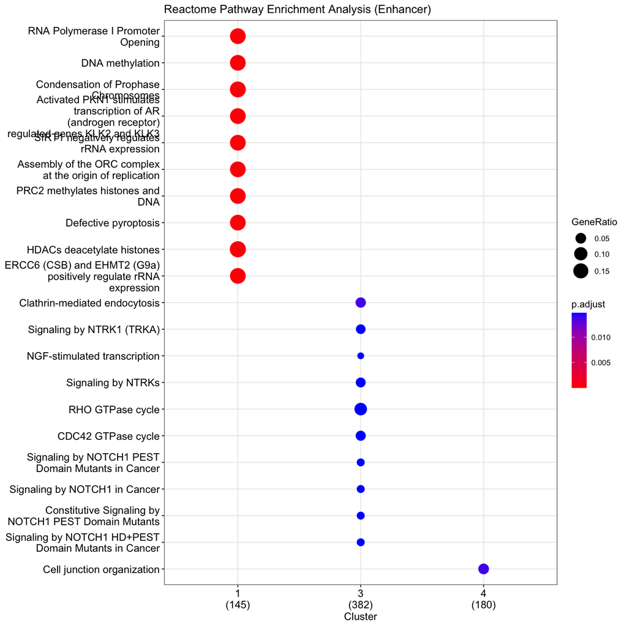

```r
> dotplot(PA.enhcr,
+         showCategory = 10,
+         title = "Reactome Pathway Enrichment Analysis (Enhancer)")
```

## Gene Ontology enrichment analysis

Exactly the same as above can be done with the function `enrichGO`.

```r
> # GO Enrichment:
> GO.enhcr <- compareCluster(geneCluster = genes,
+                            fun = "enrichGO",
+                            OrgDb = org.Hs.eg.db,
+                            ont = "BP",
+                            readable = T,
+                            pvalueCutoff = 0.05,
+                            pAdjustMethod = "BH")
>
> GO.enhcr %>% as.data.frame() %>% paged_table()
```

| Cluster | ID | Description | GeneRatio | BgRatio | pvalue | p.adjust | qvalue | geneID | Count |
| --- | --- | --- | --- | --- | --- | --- | --- | --- | --- |
| 1 | GO:0006334 | nucleosome assembly | 20/226 | 118/18614 | 1.485429e-17 | 4.341908e-14 | 4.218618e-14 | H1-2/H1-4/H1-6/H2BC14/H2BC15/H2BC21/H2BC3/H2BC4/H2BC7/H2BC8/H3C14/H3C15/H3C3/H3C4/H4C11/H4C12/H4C2/H4C3/H4C8/H4C9 | 20 |
| 1 | GO:0034728 | nucleosome organization | 20/226 | 138/18614 | 3.568334e-16 | 5.215120e-13 | 5.067035e-13 | H1-2/H1-4/H1-6/H2BC14/H2BC15/H2BC21/H2BC3/H2BC4/H2BC7/H2BC8/H3C14/H3C15/H3C3/H3C4/H4C11/H4C12/H4C2/H4C3/H4C8/H4C9 | 20 |
| 1 | GO:0002181 | cytoplasmic translation | 19/226 | 159/18614 | 7.495631e-14 | 7.303243e-11 | 7.095864e-11 | DPH5/RPL10A/RPL13A/RPL17/RPL18/RPL18A/RPL22L1/RPL27A/RPL30/RPL36A/RPL37/RPL37A/RPS12/RPS15A/RPS23/RPS26/RPS27A/RPS28/RPSA | 19 |
| 1 | GO:0065004 | protein-DNA complex assembly | 21/226 | 242/18614 | 2.010937e-12 | 1.469492e-09 | 1.427765e-09 | H1-2/H1-4/H1-6/H2BC14/H2BC15/H2BC21/H2BC3/H2BC4/H2BC7/H2BC8/H3C14/H3C15/H3C3/H3C4/H4C11/H4C12/H4C2/H4C3/H4C8/H4C9/TAF12 | 21 |
| 1 | GO:0071824 | protein-DNA complex subunit organization | 21/226 | 263/18614 | 9.933039e-12 | 5.806855e-09 | 5.641966e-09 | H1-2/H1-4/H1-6/H2BC14/H2BC15/H2BC21/H2BC3/H2BC4/H2BC7/H2BC8/H3C14/H3C15/H3C3/H3C4/H4C11/H4C12/H4C2/H4C3/H4C8/H4C9/TAF12 | 21 |
| 1 | GO:0061644 | protein localization to CENP-A containing chromatin | 7/226 | 18/18614 | 1.006826e-09 | 4.904920e-07 | 4.765642e-07 | H2AC8/H4C11/H4C12/H4C2/H4C3/H4C8/H4C9 | 7 |
| 1 | GO:0071168 | protein localization to chromatin | 9/226 | 54/18614 | 1.618020e-08 | 6.756389e-06 | 6.564538e-06 | H2AC8/H4C11/H4C12/H4C2/H4C3/H4C8/H4C9/PLK1/ZMYND8 | 9 |
| 1 | GO:0006338 | chromatin remodeling | 21/226 | 402/18614 | 2.229802e-08 | 8.147139e-06 | 7.915797e-06 | H1-2/H1-4/H1-6/H2BC14/H2BC15/H2BC21/H2BC3/H2BC4/H2BC7/H2BC8/H3C14/H3C15/H3C3/H3C4/H4C11/H4C12/H4C2/H4C3/H4C8/H4C9/SPHK2 | 21 |
| 1 | GO:0045653 | negative regulation of megakaryocyte differentiation | 6/226 | 20/18614 | 1.007913e-07 | 3.273477e-05 | 3.180525e-05 | H4C11/H4C12/H4C2/H4C3/H4C8/H4C9 | 6 |
| 1 | GO:0071459 | protein localization to chromosome, centromeric region | 7/226 | 43/18614 | 7.875927e-07 | 2.302133e-04 | 2.236763e-04 | H2AC8/H4C11/H4C12/H4C2/H4C3/H4C8/H4C9 | 7 |

[output cut: 149 more lines]

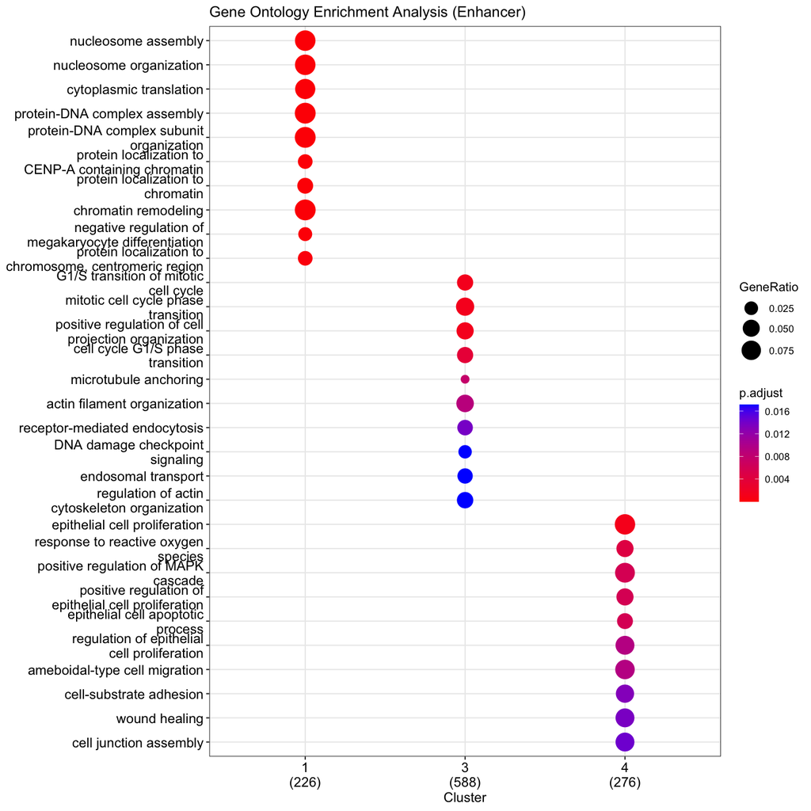

```r
> dotplot(GO.enhcr,
+         showCategory = 10,
+         title = "Gene Ontology Enrichment Analysis (Enhancer)")
```

## References - packages

- Allaire J, Xie Y, Dervieux C, McPherson J, Luraschi J, Ushey K, Atkins A, Wickham H, Cheng J, Chang W, Iannone R (2023). *rmarkdown: Dynamic Documents for R*. R package version 2.23, https://github.com/rstudio/rmarkdown. Xie Y, Allaire J, Grolemund G (2018). *R Markdown: The Definitive Guide*. Chapman and Hall/CRC, Boca Raton, Florida. ISBN 9781138359338, https://bookdown.org/yihui/rmarkdown. Xie Y, Dervieux C, Riederer E (2020). *R Markdown Cookbook*. Chapman and Hall/CRC, Boca Raton, Florida. ISBN 9780367563837, https://bookdown.org/yihui/rmarkdown-cookbook.
- Arora S, Morgan M, Carlson M, Pagès H (2023). *GenomeInfoDb: Utilities for manipulating chromosome names, including modifying them to follow a particular naming style*. doi:10.18129/B9.bioc.GenomeInfoDb https://doi.org/10.18129/B9.bioc.GenomeInfoDb, R package version 1.36.0, https://bioconductor.org/packages/GenomeInfoDb.
- Carlson M (2023). *org.Hs.eg.db: Genome wide annotation for Human*. R package version 3.17.0.
- Grolemund G, Wickham H (2011). “Dates and Times Made Easy with lubridate.” *Journal of Statistical Software*, *40*(3), 1-25. https://www.jstatsoft.org/v40/i03/.
- Huber W, Carey VJ, Gentleman R, Anders S, Carlson M, Carvalho BS, Bravo HC, Davis S, Gatto L, Girke T, Gottardo R, Hahne F, Hansen KD, Irizarry RA, Lawrence M, Love MI, MacDonald J, Obenchain V, Ole’s AK, Pag`es H, Reyes A, Shannon P, Smyth GK, Tenenbaum D, Waldron L, Morgan M (2015). “Orchestrating high-throughput genomic analysis with Bioconductor.” *Nature Methods*, *12*(2), 115-121. http://www.nature.com/nmeth/journal/v12/n2/full/nmeth.3252.html.
- Huber, W., Carey, J. V, Gentleman, R., Anders, S., Carlson, M., Carvalho, S. B, Bravo, C. H, Davis, S., Gatto, L., Girke, T., Gottardo, R., Hahne, F., Hansen, D. K, Irizarry, A. R, Lawrence, M., Love, I. M, MacDonald, J., Obenchain, V., Ole’s, K. A, Pag`es, H., Reyes, A., Shannon, P., Smyth, K. G, Tenenbaum, D., Waldron, L., Morgan, M. (2015). “Orchestrating high-throughput genomic analysis with Bioconductor.” *Nature Methods*, *12*(2), 115-121. http://www.nature.com/nmeth/journal/v12/n2/full/nmeth.3252.html.
- Lawrence M, Gentleman R, Carey V (2009). “rtracklayer: an R package for interfacing with genome browsers.” *Bioinformatics*, *25*, 1841-1842. doi:10.1093/bioinformatics/btp328 https://doi.org/10.1093/bioinformatics/btp328, http://bioinformatics.oxfordjournals.org/content/25/14/1841.abstract.
- Lawrence M, Huber W, Pagès H, Aboyoun P, Carlson M, Gentleman R, Morgan M, Carey V (2013). “Software for Computing and Annotating Genomic Ranges.” *PLoS Computational Biology*, *9*. doi:10.1371/journal.pcbi.1003118 https://doi.org/10.1371/journal.pcbi.1003118, http://www.ploscompbiol.org/article/info%3Adoi%2F10.1371%2Fjournal.pcbi.1003118.
- Lawrence M, Huber W, Pagès H, Aboyoun P, Carlson M, Gentleman R, Morgan M, Carey V (2013). “Software for Computing and Annotating Genomic Ranges.” *PLoS Computational Biology*, *9*. doi:10.1371/journal.pcbi.1003118 https://doi.org/10.1371/journal.pcbi.1003118, http://www.ploscompbiol.org/article/info%3Adoi%2F10.1371%2Fjournal.pcbi.1003118.
- Makowski D, Lüdecke D, Patil I, Thériault R, Ben-Shachar M, Wiernik B (2023). “Automated Results Reporting as a Practical Tool to Improve Reproducibility and Methodological Best Practices Adoption.” *CRAN*. https://easystats.github.io/report/.
- Müller K, Wickham H (2023). *tibble: Simple Data Frames*. R package version 3.2.1, https://CRAN.R-project.org/package=tibble.
- Pagès H, Carlson M, Falcon S, Li N (2023). *AnnotationDbi: Manipulation of SQLite-based annotations in Bioconductor*. doi:10.18129/B9.bioc.AnnotationDbi https://doi.org/10.18129/B9.bioc.AnnotationDbi, R package version 1.62.1, https://bioconductor.org/packages/AnnotationDbi.
- Pagès H, Lawrence M, Aboyoun P (2023). *S4Vectors: Foundation of vector-like and list-like containers in Bioconductor*. doi:10.18129/B9.bioc.S4Vectors https://doi.org/10.18129/B9.bioc.S4Vectors, R package version 0.38.1, https://bioconductor.org/packages/S4Vectors.
- R Core Team (2023). *R: A Language and Environment for Statistical Computing*. R Foundation for Statistical Computing, Vienna, Austria. https://www.R-project.org/.
- Wang Q, Li M, Wu T, Zhan L, Li L, Chen M, Xie W, Xie Z, Hu E, Xu S, Yu G (2022). “Exploring epigenomic datasets by ChIPseeker.” *Current Protocols*, *2*(10), e585. doi:10.1002/cpz1.585 https://doi.org/10.1002/cpz1.585, https://onlinelibrary.wiley.com/share/author/GYJGUBYCTRMYJFN2JFZZ?target=10.1002/cpz1.585. Yu G, Wang L, He Q (2015). “ChIPseeker: an R/Bioconductor package for ChIP peak annotation, comparison and visualization.” *Bioinformatics*, *31*(14), 2382-2383. doi:10.1093/bioinformatics/btv145 https://doi.org/10.1093/bioinformatics/btv145.
- Wickham H (2016). *ggplot2: Elegant Graphics for Data Analysis*. Springer-Verlag New York. ISBN 978-3-319-24277-4, https://ggplot2.tidyverse.org.
- Wickham H (2022). *stringr: Simple, Consistent Wrappers for Common String Operations*. R package version 1.5.0, https://CRAN.R-project.org/package=stringr.
- Wickham H (2023). *forcats: Tools for Working with Categorical Variables (Factors)*. R package version 1.0.0, https://CRAN.R-project.org/package=forcats.
- Wickham H, Averick M, Bryan J, Chang W, McGowan LD, François R, Grolemund G, Hayes A, Henry L, Hester J, Kuhn M, Pedersen TL, Miller E, Bache SM, Müller K, Ooms J, Robinson D, Seidel DP, Spinu V, Takahashi K, Vaughan D, Wilke C, Woo K, Yutani H (2019). “Welcome to the tidyverse.” *Journal of Open Source Software*, *4*(43), 1686. doi:10.21105/joss.01686 https://doi.org/10.21105/joss.01686.
- Wickham H, François R, Henry L, Müller K, Vaughan D (2023). *dplyr: A Grammar of Data Manipulation*. R package version 1.1.2, https://CRAN.R-project.org/package=dplyr.
- Wickham H, Henry L (2023). *purrr: Functional Programming Tools*. R package version 1.0.1, https://CRAN.R-project.org/package=purrr.
- Wickham H, Hester J, Bryan J (2023). *readr: Read Rectangular Text Data*. R package version 2.1.4, https://CRAN.R-project.org/package=readr.
- Wickham H, Vaughan D, Girlich M (2023). *tidyr: Tidy Messy Data*. R package version 1.3.0, https://CRAN.R-project.org/package=tidyr.
- Wu T, Hu E, Xu S, Chen M, Guo P, Dai Z, Feng T, Zhou L, Tang W, Zhan L, Fu x, Liu S, Bo X, Yu G (2021). “clusterProfiler 4.0: A universal enrichment tool for interpreting omics data.” *The Innovation*, *2*(3), 100141. doi:10.1016/j.xinn.2021.100141 https://doi.org/10.1016/j.xinn.2021.100141. Yu G, Wang L, Han Y, He Q (2012). “clusterProfiler: an R package for comparing biological themes among gene clusters.” *OMICS: A Journal of Integrative Biology*, *16*(5), 284-287. doi:10.1089/omi.2011.0118 https://doi.org/10.1089/omi.2011.0118.
- Xie Y (2023). *knitr: A General-Purpose Package for Dynamic Report Generation in R*. R package version 1.43, https://yihui.org/knitr/. Xie Y (2015). *Dynamic Documents with R and knitr*, 2nd edition. Chapman and Hall/CRC, Boca Raton, Florida. ISBN 978-1498716963, https://yihui.org/knitr/. Xie Y (2014). “knitr: A Comprehensive Tool for Reproducible Research in R.” In Stodden V, Leisch F, Peng RD (eds.), *Implementing Reproducible Computational Research*. Chapman and Hall/CRC. ISBN 978-1466561595.

## Session Information

The following versions of R and R packages were used to generate the report above: